# AirQuality Dataset Exploratoration

To explore the impact of weather trends on Citibike ridership in New York City, we used [Air Quality](https://data.cityofnewyork.us/Environment/Air-Quality/c3uy-2p5r) dataset from the [NYC Open Data](https://opendata.cityofnewyork.us/), provided by the Department of Hygiene and Mental Health.

This dataset includes air quality indexes measured across NYC boroughs. Our analysis aims to uncover relationships between air quality variations and Citibike ridership, offering insights into how environmental factors influence urban mobility patterns.

## Air Quality Exploratory analyses

We first import data and tidy `Air Qality` dataset.

```r
#import data
air <- read_csv(here("data/air_quality/Air_Quality_20231126.csv"))
joined_uhf_34_42 <- read_csv(here("data/geocoding/joined_uhf_34_42.csv"))

#Air Quality tidy
air_quality_df = air |>
  janitor::clean_names() |>
  mutate(
    start_date = mdy(start_date),
    year = year(start_date)
  ) |>
  filter(year == "2019")
```

Added zip codes. The original data includes several varieties of `geo ids, including borough, citywide, uhf42, ,uhf34, and CD` (Community Districts). We decided to use `uhf42` and `uhf34` with `zipcodes`, so the other geo id varieties will be filtered out.

```r
# add zip codes
air_geo =
  air_quality_df |>
  mutate(
    uhf42 = case_when(geo_type_name == "UHF42" ~ "1"),
    uhf34 = case_when(geo_type_name == "UHF34" ~ "1")
  )

#break up by geocoding system, add zipcodes
#uhf42
air_zip_neighborhoods_42 =
  air_geo |>
  filter(uhf42 == "1") |>
  select(-uhf42, -uhf34, - message)

air_zip_neighborhoods_42 =
  left_join(air_zip_neighborhoods_42, y = (joined_uhf_34_42),
            by = join_by("geo_join_id" == "uhf42"))

air_zip_neighborhoods_42 =
  air_zip_neighborhoods_42 |>
  select(-uhf34, -uhf34_neighborhood, -uhf42_neighborhood) |>
filter(!duplicated(unique_id))

# uhf34
air_zip_neighborhoods_34 =
  air_geo |>
  filter(uhf34 == "1") |>
  select(-uhf42, -uhf34, - message)

air_zip_neighborhoods_34 =
  left_join(air_zip_neighborhoods_34, y = (joined_uhf_34_42),
            by = join_by("geo_join_id" == "uhf34"))

air_zip_neighborhoods_34 =
  air_zip_neighborhoods_34 |>
  select(-uhf34_neighborhood, -uhf42_neighborhood, - uhf42) |>
filter(!duplicated(unique_id))

# bind uhf frames
air_zip_uhf =
  bind_rows(air_zip_neighborhoods_34, air_zip_neighborhoods_42)

# save output for ease in other files
write_csv(air_zip_uhf, here("data/air_quality/air_zip_uhf.csv"))
```

### Average Air Quality Index Across Time Periods, UHF Neighborhoods only

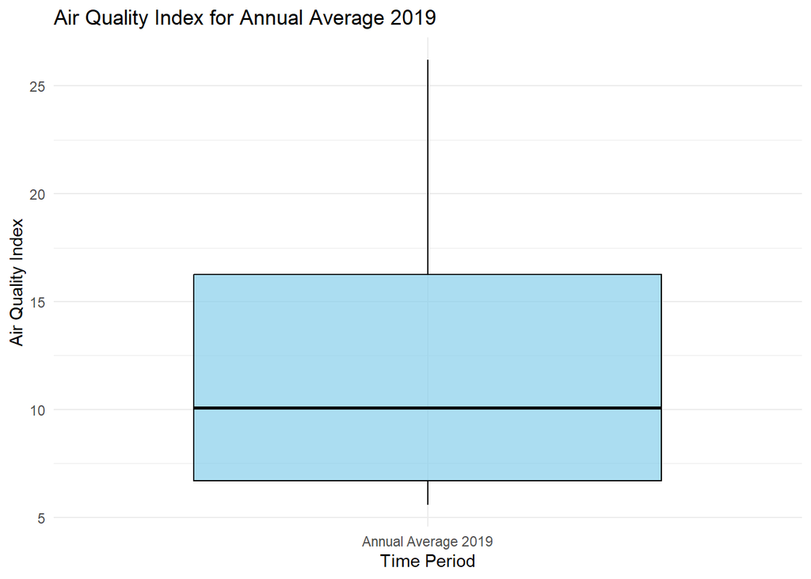

```r
annual_aq = air_zip_uhf |>
  filter(time_period == "Annual Average 2019")

annual_aq|>
  ggplot(aes(x = time_period, y = data_value)) +
  geom_boxplot(fill = "skyblue", color = "black", alpha = 0.7) +
  labs(title = "Air Quality Index for Annual Average 2019",
       x = "Time Period",
       y = "Air Quality Index") +
  theme_minimal()
```

```r
# Calculate statistics
midpoint <- median(annual_aq$data_value)
low_quantile <- quantile(annual_aq$data_value, 0.25)
top_quantile <- quantile(annual_aq$data_value, 0.75)
```

- There are three time periods: Annual average 2019, Winer 2019-20, Summer 2019.
- The range of values is from 5.59 - 26.22. Midpoint is 10.065, low quantile is 6.7, and high quantile is 16.27.

### We have evaluated three data particles: Fine particles (PM 2.5), Nitrogen dioxide (NO2), and Ozone (O3).

- There is variability in values based by geopgraphic location.

### Air Quality Comparison, Fine Particles, UHF Neighborhoods Only, Annual Average

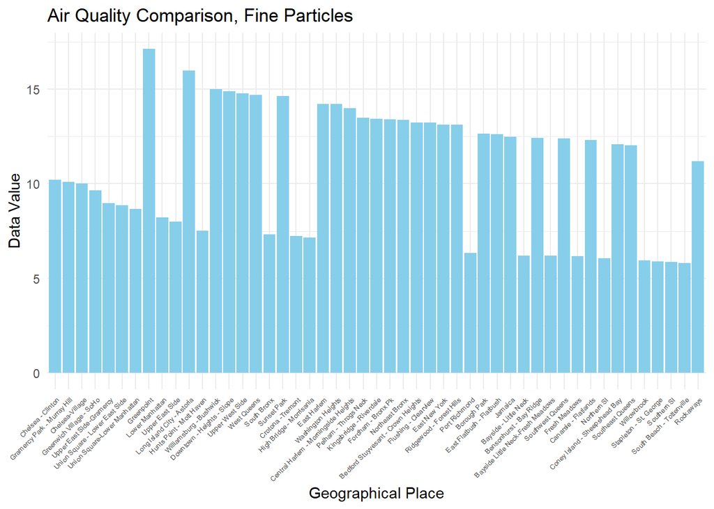

```r
air_particles =
  air_zip_uhf |>
  filter(name == "Fine particles (PM 2.5)")

air_particles |>
  filter(time_period == "Annual Average 2019") |>
  ggplot(aes(x = reorder(geo_place_name, -data_value), y = data_value)) +
  geom_bar(stat = "identity", fill = "skyblue")  +
  labs(title = "Air Quality Comparison, Fine Particles",
       x = "Geographical Place",
       y = "Data Value") +
  theme_minimal() +
  theme(axis.text.x = element_text(angle = 45, hjust = 1, size = 5))
```

- The highest concentration of Fine particles was in Greenpoint, with the lowest in South beach - Tottenville.

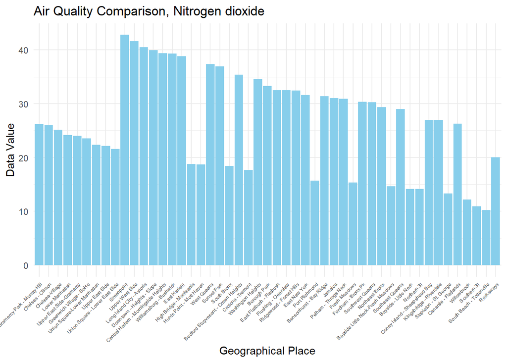

```r
air_nitrogen =
  air_zip_uhf |>
  filter(name == "Nitrogen dioxide (NO2)")

air_nitrogen |>
  filter(time_period == "Annual Average 2019") |>
  ggplot(aes(x = reorder(geo_place_name, -data_value), y = data_value)) +
  geom_bar(stat = "identity", fill = "skyblue")  +
  labs(title = "Air Quality Comparison, Nitrogen dioxide",
       x = "Geographical Place",
       y = "Data Value") +
  theme_minimal() +
  theme(axis.text.x = element_text(angle = 45, hjust = 1, size = 5))
```

- Again the highest concentration of this measure, Nitrogen dioxide, was in Greenpoint, and lowest in South beach - Tottenville.

### Air Quality Comparison, UHF Neighborhoods Only, Ozone

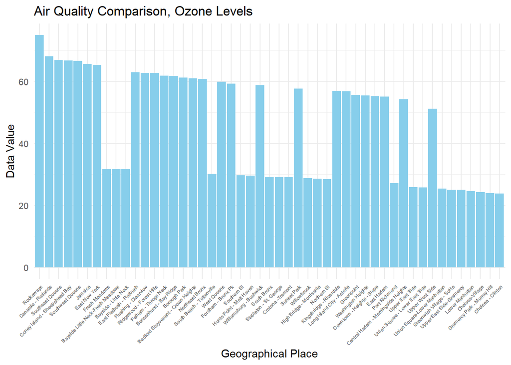

```r
air_zip_uhf |>
  filter(name == "Ozone (O3)") |>
  ggplot(aes(x = reorder(geo_place_name, -data_value), y = data_value)) +
  geom_bar(stat = "identity", fill = "skyblue") +
  labs(title = "Air Quality Comparison, Ozone Levels",
       x = "Geographical Place",
       y = "Data Value") +
  theme_minimal() +
  theme(axis.text.x = element_text(angle = 45, hjust = 1, size = 5))
```

- The higest value of Ozone concentrations was in Rockaways, but the lowest was in Chelsea - Clinton.

### The minimum, first quartile (Q1), median, third quartile (Q3), and maximum values for each pollutant.

```r
air_quality_df |>
  group_by(name) |>
  summarise(
    min_value = min(data_value, na.rm = TRUE),
    q1 = quantile(data_value, 0.25, na.rm = TRUE),
    median_value = median(data_value, na.rm = TRUE),
    q3 = quantile(data_value, 0.75, na.rm = TRUE),
    max_value = max(data_value, na.rm = TRUE)
  )
```

```
## # A tibble: 3 × 6
##   name                    min_value    q1 median_value    q3 max_value
##   <chr>                       <dbl> <dbl>        <dbl> <dbl>     <dbl>
## 1 Fine particles (PM 2.5)      5.59  6.97         7.55  8.19      12.6
## 2 Nitrogen dioxide (NO2)       7.22 14.4         18.2  23.4       36.2
## 3 Ozone (O3)                  23.0  27.8         29.7  31.3       37.5
```

### The minimum, first quartile (Q1), median, third quartile (Q3), and maximum values for each pollutant. (UHF Neighborhoods Only)

```r
air_zip_uhf |>
  group_by(name) |>
  summarise(
    min_value = min(data_value, na.rm = TRUE),
    q1 = quantile(data_value, 0.25, na.rm = TRUE),
    median_value = median(data_value, na.rm = TRUE),
    q3 = quantile(data_value, 0.75, na.rm = TRUE),
    max_value = max(data_value, na.rm = TRUE)
  )
```

```
## # A tibble: 3 × 6
##   name                    min_value    q1 median_value    q3 max_value
##   <chr>                       <dbl> <dbl>        <dbl> <dbl>     <dbl>
## 1 Fine particles (PM 2.5)      5.59  6.98         7.53  8.23      11.4
## 2 Nitrogen dioxide (NO2)       7.33 14.3         18.4  23.0       34.2
## 3 Ozone (O3)                  23.8  27.7         29.6  31.3       37.4
```

### Distribution of Air Quality Pollutants

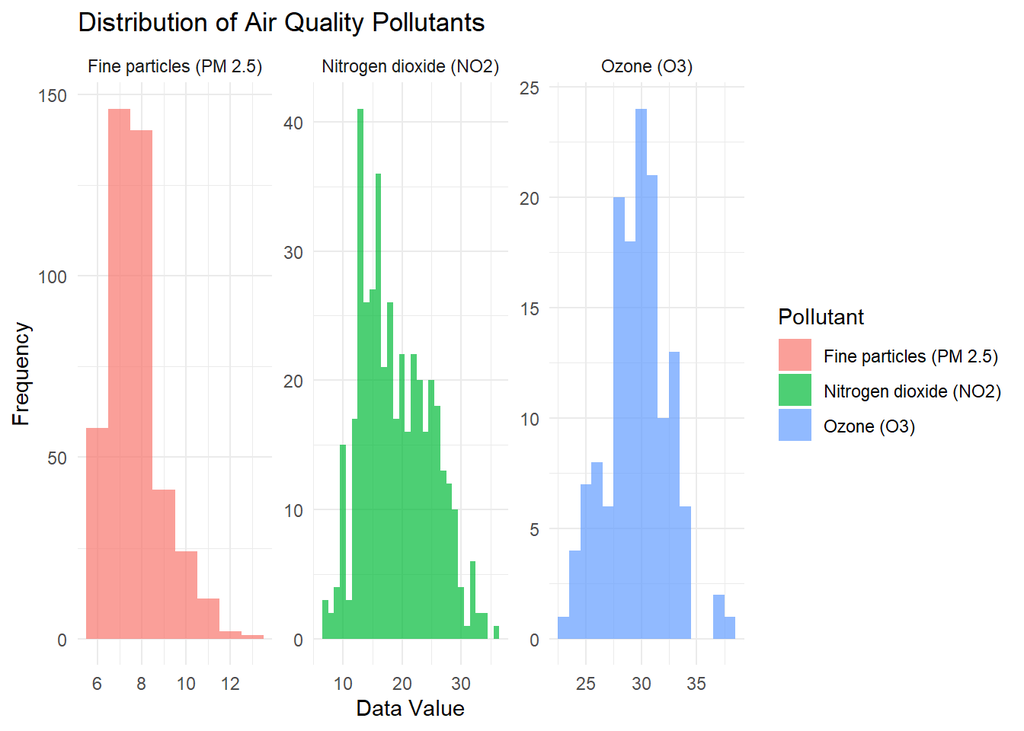

```r
air_quality_df |>
  ggplot(aes(x = data_value, fill = name)) +
  geom_histogram(binwidth = 1, position = "dodge", alpha = 0.7) +
  facet_wrap(~ name, scales = "free") +
  labs(title = "Distribution of Air Quality Pollutants",
       x = "Data Value",
       y = "Frequency",
       fill = "Pollutant") +
  theme_minimal()
```

### Distribution of Air Quality Pollutants, UHF Neighborhoods Only

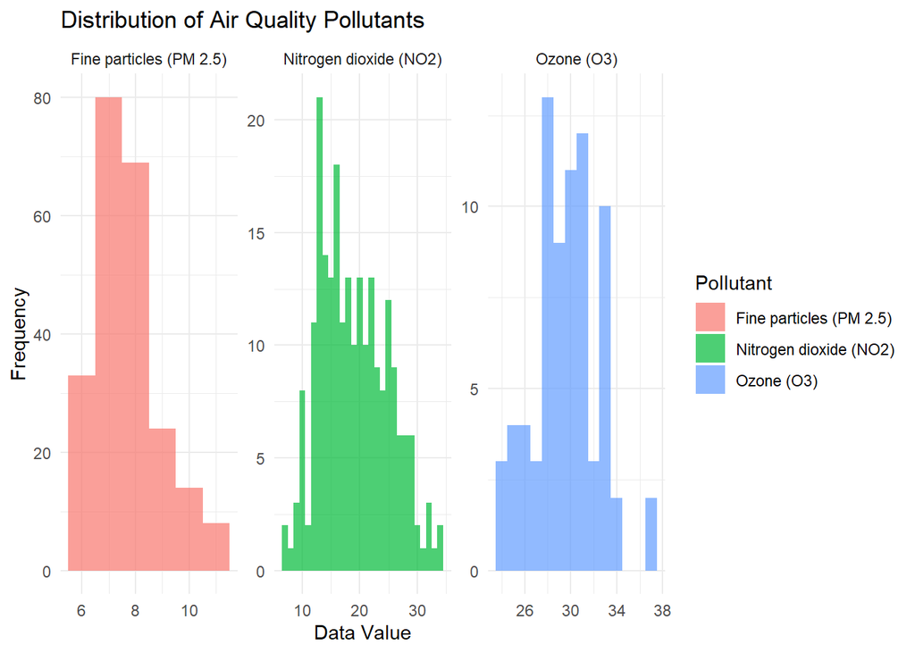

```r
air_zip_uhf |>
  ggplot(aes(x = data_value, fill = name)) +
  geom_histogram(binwidth = 1, position = "dodge", alpha = 0.7) +
  facet_wrap(~ name, scales = "free") +
  labs(title = "Distribution of Air Quality Pollutants",
       x = "Data Value",
       y = "Frequency",
       fill = "Pollutant") +
  theme_minimal()
```